# The analysis of spatial patterns of the electric vehicle charge points in London between 2019 and 2020

Zeqiang Fang

2021/1/08

## 1.Import packages

If there are errors take place, you can run `install.packages({missing package name})` to install packages.

```r
library(tidyverse)
library(data.table)
library(sp)
library(sf)
library(table1)
library(tm)
library(spatstat)
library(here)
library(sp)
library(rgeos)
```

```r
library(maptools)
library(tmap)
library(sf)
library(geojson)
library(geojsonio)
library(tmaptools)
library(RColorBrewer)
library(spdep)
```

## 2. The basic settings

### 2.1 Set the path of your project.

The path below is mine, you should set your own work path

```r
setwd("/Users/fangzeqiang/Desktop/SDSV/Final/CASA0005_Final_Assessment/")
```

### 2.2 Import the shape file

What you should keep in mind is that this shape file should be run in the complete ESRI dir

```r
# London_Borough=st_read("F:/spat/statistical-gis-boundaries-london/ESRI/London_Borough_Excluding_MHW.shp")
London_Borough = st_read("dataset/statistical-gis-boundaries-london/ESRI/London_Borough_Excluding_MHW.shp")
```

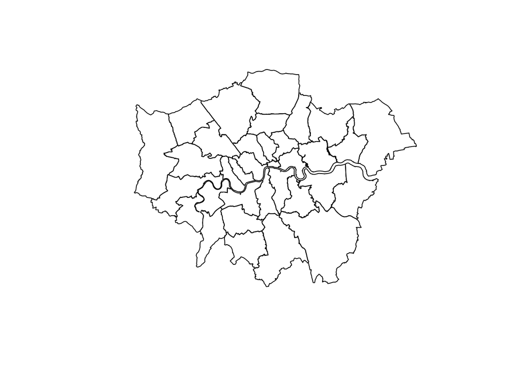

```r
# plot the map
plot(st_geometry(London_Borough))
```

### 2.3 import the London national chargepoint register dataset

```r
df = fread("Dataset/London_NCR_GSS_Added.csv")
```

## 3. The distribution of samples

```r
#3.1 select the years
df$year = year(df$dateCreated)
table(df$year)
```

```
##
## 2017 2018 2019 2020 2021
##    1    4  696  362    3
```

```r
#select 2019 & 2020
df = df[year==2019|year==2020,]
table(df$year)
```

```
##
## 2019 2020
##  696  362
```

```r
#3.2 show the table of the distribution of two years samples
table1(~town|factor(year),data=df)
```

|  | 2019 (N=696) | 2020 (N=362) | Overall (N=1058) |
| --- | --- | --- | --- |
| town |  |  |  |
| Brentford | 3 (0.4%) | 0 (0%) | 3 (0.3%) |
| Brixton | 1 (0.1%) | 0 (0%) | 1 (0.1%) |
| Brixton, London | 4 (0.6%) | 0 (0%) | 4 (0.4%) |
| Camden | 1 (0.1%) | 1 (0.3%) | 2 (0.2%) |
| Chiswick, London | 7 (1.0%) | 0 (0%) | 7 (0.7%) |
| Cricklewood | 7 (1.0%) | 0 (0%) | 7 (0.7%) |
| Crystal Palace | 1 (0.1%) | 0 (0%) | 1 (0.1%) |
| Dollis Hill | 7 (1.0%) | 0 (0%) | 7 (0.7%) |
| Dulwich | 1 (0.1%) | 0 (0%) | 1 (0.1%) |
| East Dulwicj | 1 (0.1%) | 0 (0%) | 1 (0.1%) |
| Feltham | 5 (0.7%) | 0 (0%) | 5 (0.5%) |
| Greenford | 1 (0.1%) | 0 (0%) | 1 (0.1%) |
| Haringey | 1 (0.1%) | 19 (5.2%) | 20 (1.9%) |
| Harlesden | 4 (0.6%) | 0 (0%) | 4 (0.4%) |
| Harlesden | 5 (0.7%) | 0 (0%) | 5 (0.5%) |
| Herne Hill | 2 (0.3%) | 0 (0%) | 2 (0.2%) |
| Herne Hill | 1 (0.1%) | 0 (0%) | 1 (0.1%) |
| Honor Oak | 1 (0.1%) | 0 (0%) | 1 (0.1%) |
| Hounslow | 1 (0.1%) | 0 (0%) | 1 (0.1%) |
| Kensal Green | 28 (4.0%) | 0 (0%) | 28 (2.6%) |
| Kilburn | 11 (1.6%) | 0 (0%) | 11 (1.0%) |
| Kilburn | 1 (0.1%) | 0 (0%) | 1 (0.1%) |
| London | 519 (74.6%) | 285 (78.7%) | 804 (76.0%) |
| London | 34 (4.9%) | 0 (0%) | 34 (3.2%) |
| North Maida vale | 6 (0.9%) | 0 (0%) | 6 (0.6%) |
| North Maida Vale | 3 (0.4%) | 0 (0%) | 3 (0.3%) |
| Nunhead | 2 (0.3%) | 0 (0%) | 2 (0.2%) |
| Nunhead | 1 (0.1%) | 0 (0%) | 1 (0.1%) |
| Queen's Park | 4 (0.6%) | 0 (0%) | 4 (0.4%) |
| Richmond | 3 (0.4%) | 3 (0.8%) | 6 (0.6%) |
| South Woodford | 1 (0.1%) | 0 (0%) | 1 (0.1%) |
| Southall | 4 (0.6%) | 7 (1.9%) | 11 (1.0%) |
| Surrey Quays | 2 (0.3%) | 0 (0%) | 2 (0.2%) |
| Twickenham | 3 (0.4%) | 2 (0.6%) | 5 (0.5%) |
| Wanstead | 8 (1.1%) | 0 (0%) | 8 (0.8%) |
| Wembley | 9 (1.3%) | 0 (0%) | 9 (0.9%) |
| West Norwood | 3 (0.4%) | 0 (0%) | 3 (0.3%) |
| Barnet | 0 (0%) | 1 (0.3%) | 1 (0.1%) |
| Brent | 0 (0%) | 3 (0.8%) | 3 (0.3%) |
| Croydon | 0 (0%) | 7 (1.9%) | 7 (0.7%) |
| Hackney | 0 (0%) | 1 (0.3%) | 1 (0.1%) |
| Haringey | 0 (0%) | 1 (0.3%) | 1 (0.1%) |
| Harrow | 0 (0%) | 1 (0.3%) | 1 (0.1%) |
| Hayes | 0 (0%) | 3 (0.8%) | 3 (0.3%) |
| Islington | 0 (0%) | 1 (0.3%) | 1 (0.1%) |
| Lambeth | 0 (0%) | 4 (1.1%) | 4 (0.4%) |
| Lewisham | 0 (0%) | 1 (0.3%) | 1 (0.1%) |
| Merton | 0 (0%) | 2 (0.6%) | 2 (0.2%) |
| Newham | 0 (0%) | 1 (0.3%) | 1 (0.1%) |
| Redbridge | 0 (0%) | 1 (0.3%) | 1 (0.1%) |
| Stratford | 0 (0%) | 7 (1.9%) | 7 (0.7%) |
| Teddington | 0 (0%) | 1 (0.3%) | 1 (0.1%) |
| Uxbridge | 0 (0%) | 3 (0.8%) | 3 (0.3%) |
| Waltham Forest | 0 (0%) | 1 (0.3%) | 1 (0.1%) |
| Westminster | 0 (0%) | 6 (1.7%) | 6 (0.6%) |

## 4. Visualisation and comparison of the density of London EV charge point between two years

### 4.1 Data cleaning for mapping

- I divided the dataset into ones in two years, and merged these two processed dataset with geometric data.
- Then we calculate the density for two years.
- Finally we can visualise and map the density

```r
#5.1 process the data to divide them by years(2019 & 2020)
df1<-subset(df,year==2019) #2019年
df2<-subset(df,year==2020) #2020年

# EV charge points created in 2019
# sdf1<-merge(London_Borough,df1,by="GSS_CODE")
sdf1<-merge(London_Borough,df1,by="GSS_CODE",all = TRUE)
sdf1<-sdf1[,c("GSS_CODE","geometry","longitude","latitude")]

# EV charge points created in 2020
# sdf2<-merge(London_Borough,df2,by="GSS_CODE")
sdf2<-merge(London_Borough,df2,by="GSS_CODE",all = TRUE)
sdf2<-sdf2[,c("GSS_CODE","geometry","longitude","latitude")]
```

### 4.2 The density of data in 2019

```r
# Data preparation
nsdf1 = sdf1%>%
  add_count(GSS_CODE)%>%
  mutate(area=st_area(.))%>%
  # Use dplyr::mutate to calculate the density of the charge point for each borough
  mutate(density=n/area)

# select the following variables---"density","GSS_CODE","n"(the count of GSS_CODE)
nsdf1 = dplyr::select(nsdf1,density,GSS_CODE, n)

nsdf1 = nsdf1%>%
  group_by(GSS_CODE)%>%
  summarise(density =first(density),GSS_CODE=first(GSS_CODE))
```

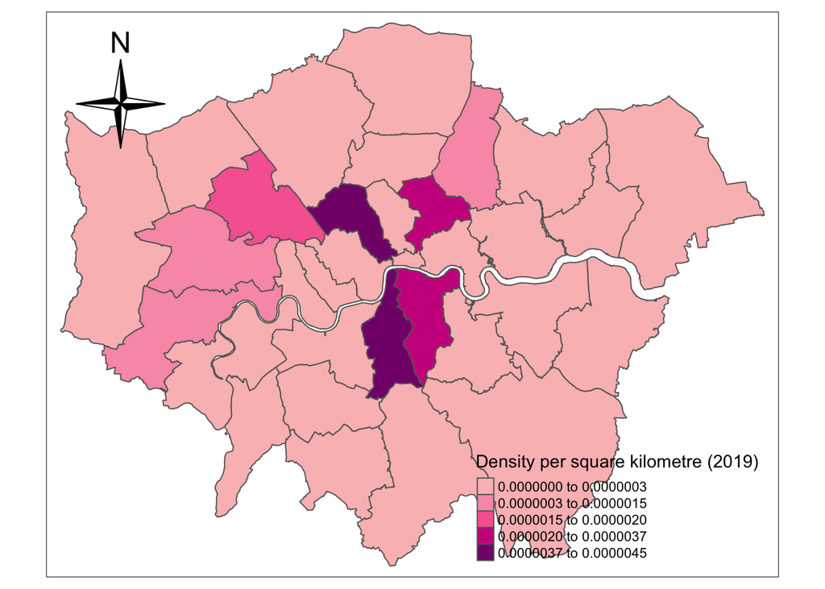

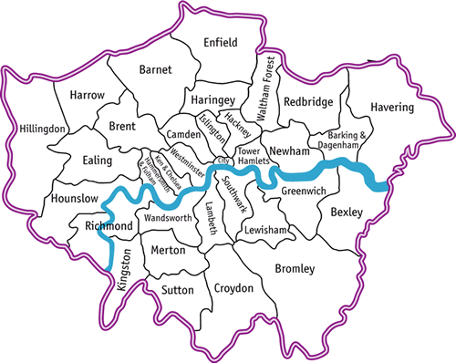

```r
# plot the figure2: The distribution of the density of the London charge points in 2019
tm_shape( nsdf1) +
  tm_compass( north = 0,
              type = "4star",
              text.size = 0.8,
              size = 2.5,
              show.labels = 1,
              cardinal.directions = c("N", "E", "S", "W"),
              lwd = 1,
              position = c("left","top"),
              bg.color = NA,
              bg.alpha = NA,
              just = NA,
              fontsize = 1.5) +
  tm_polygons("density",
              style="jenks",
              palette="RdPu",
              midpoint=NA,
              popup.vars=c("GSS_CODE", "density"),
              title="Density per square kilometre (2019)"
              )
```

### 4.3 The density of data in 2020

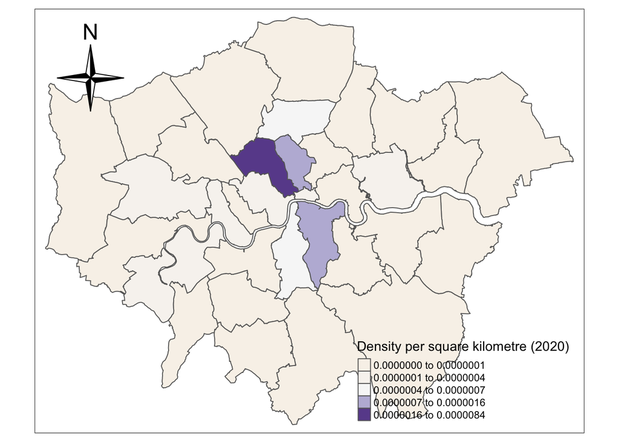

```r
nsdf2 = sdf2%>%
  add_count(GSS_CODE)%>%
  mutate(area=st_area(.))%>%
  mutate(units::set_units(area,km^2))%>%
  #then density of the points per ward
  mutate(density=n/area)

nsdf2 = dplyr::select(nsdf2,density,GSS_CODE, n)

nsdf2 = nsdf2%>%
  group_by(GSS_CODE)%>%
  summarise(density =first(density),GSS_CODE=first(GSS_CODE))
tm_shape( nsdf2) +
  tm_compass( north = 0,
              type = "4star",
              text.size = 0.8,
              size = 2.5,
              show.labels = 1,
              cardinal.directions = c("N", "E", "S", "W"),
              lwd = 1,
              position = c("left","top"),
              bg.color = NA,
              bg.alpha = NA,
              just = NA,
              fontsize = 1.5) +
  tm_polygons("density",
              style="jenks",
              palette="PuOr",
              midpoint=NA,
              popup.vars=c("GSS_CODE", "density"),
              title="Density per square kilometre (2020)")
```

## 5. Analysing Spatial Autocorrelation with Moran’s I

Since the sample in 2019 & 2020 is too small to run a good result, I analysis the autocorrelation based on the samples which contain these two yearsl

###5.1 generate the data for analysis

```r
sdf = merge(London_Borough,df,by="GSS_CODE",all = TRUE)
sdf = sdf[,c("GSS_CODE","geometry","longitude","latitude")]
nsdf = sdf%>%
  add_count(GSS_CODE)%>%
  mutate(area=st_area(.))%>%
  #then density of the points per ward
  mutate(density=n/area)

nsdf = dplyr::select(nsdf,density,GSS_CODE, n)

nsdf = nsdf%>%
  group_by(GSS_CODE)%>%
  summarise(density = first(density), GSS_CODE = first(GSS_CODE))
```

###5.2 First plot the centroids of all boroughs in London

```r
coordsW = nsdf%>%
   st_centroid()%>%
   st_geometry()
```

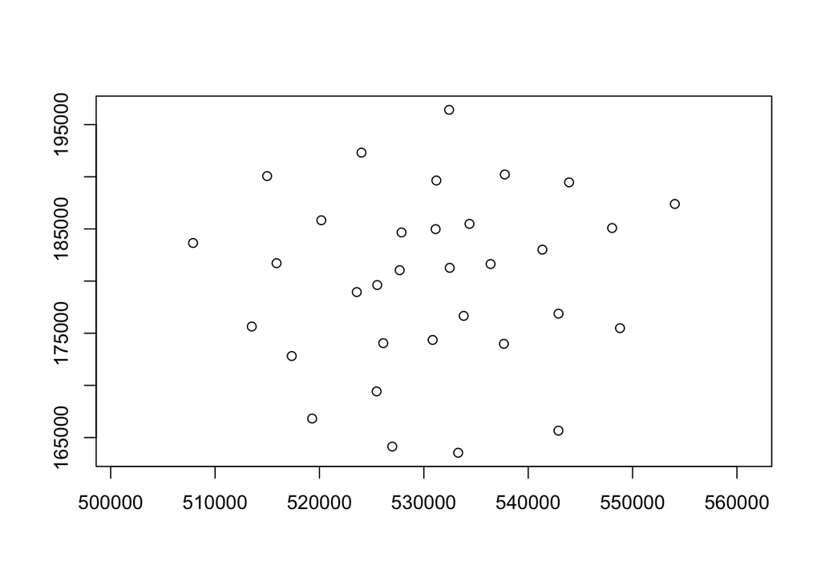

```r
 plot(coordsW,axes=TRUE)
```

### 5.3 create a neighbours list

```r
 LWard_nb <- nsdf%>%poly2nb(.,queen=T)
```

plot the neighbours list we creat

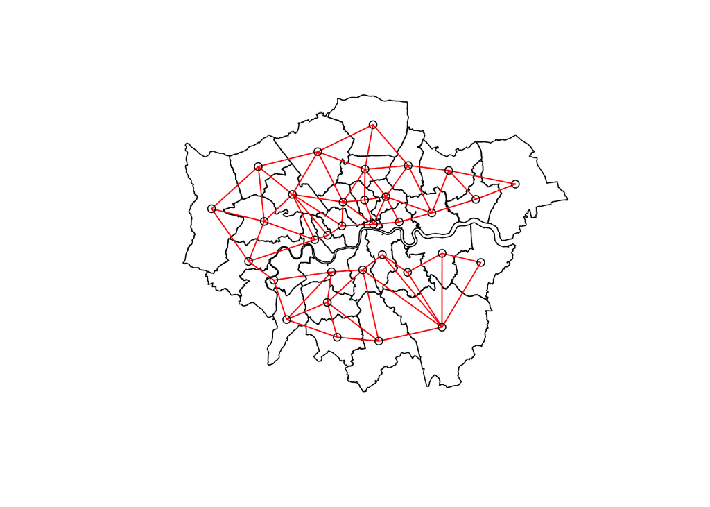

```r
plot(nsdf$geometry)
plot(LWard_nb, st_geometry(coordsW), col="red", add = T)
```

```r
# plot(LWard_nb, st_geometry(coordsW), col="red")
# plot(nsdf$geometry, add=T)
 # plot(LWard_nb, st_geometry(coordsW), col="red")
 # jpeg(file="saving_plot1.jpeg")
 # dev.off()
```

### 5.3 create a spatial weights object from these weights

```r
Lward.lw = nb2listw(LWard_nb, style="C")
head(Lward.lw$neighbours)
```

```
## [[1]]
## [1]  7 12 19 30 33
##
## [[2]]
## [1] 16 25 26
##
## [[3]]
## [1]  5  7 10 14 15
##
## [[4]]
## [1]  6 11
##
## [[5]]
## [1]  3  7  9 13 15 20 33
##
## [[6]]
## [1]  4  8 11 22 23 28
```

### 5.4 Calculate the Global Moran’I Index

- Conduct the global Moran index

```r
 I_LWard_Global_Density = nsdf %>%
   pull(density) %>%
   as.vector()%>%
   moran.test(.,Lward.lw)
```

```r
names(I_LWard_Global_Density)
```

```
## [1] "statistic"   "p.value"     "estimate"    "alternative" "method"
## [6] "data.name"
```

```r
head(I_LWard_Global_Density)
```

```
## $statistic
## Moran I statistic standard deviate
##                         0.03513093
##
## $p.value
## [1] 0.4859877
##
## $estimate
## Moran I statistic       Expectation          Variance
##      -0.028283348      -0.031250000       0.007131055
##
## $alternative
## [1] "greater"
##
## $method
## [1] "Moran I test under randomisation"
##
## $data.name
## [1] ".  \nweights: Lward.lw    \n"
```

- Conduct the Local Moran test

```r
 I_LWard_Local_Density = nsdf %>%
   pull(density) %>%
   as.vector()%>%
   localmoran(., Lward.lw)%>%
   as_tibble()
```

- Merge the moran test result with the geometric dataset

```r
nsdf<-nsdf%>%
   mutate(density_I = as.numeric(I_LWard_Local_Density$Ii))%>%
   mutate(density_Iz =as.numeric(I_LWard_Local_Density$Z.Ii))
```

### 5.5 Visulisation of the distribution of the local Moran result

```r
#set the group and colour
summary(nsdf$density_Iz)
```

```
##      Min.   1st Qu.    Median      Mean   3rd Qu.      Max.
## -1.813183 -0.007425  0.133178  0.046786  0.449411  0.975067
```

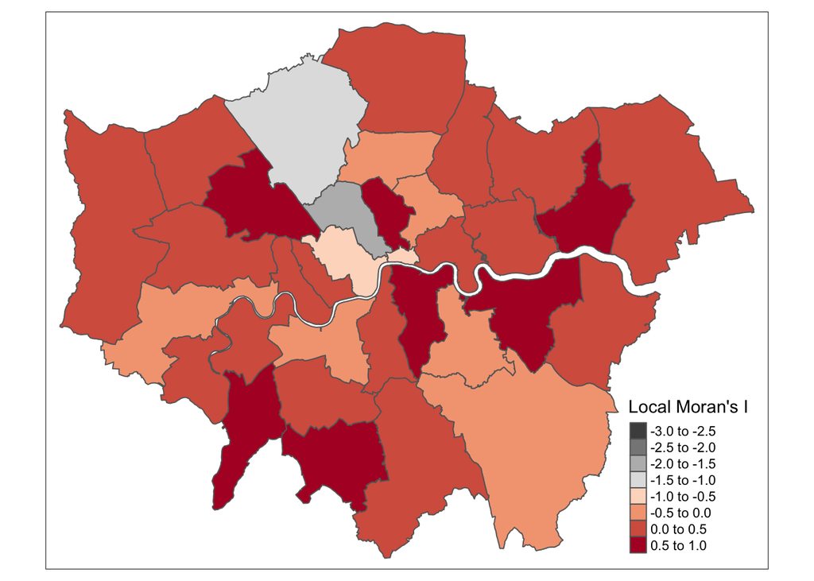

```r
breaks1<-seq(-3,1,0.5) # Depends on the max and min value in Moran's I
MoranColours<- rev(brewer.pal(8, "RdGy"))

# Plot the map
tm_shape(nsdf) +
  tm_polygons("density_Iz",
              style="fixed",
              breaks=breaks1,
              palette=MoranColours,
              midpoint=NA,
              title="Local Moran's I")
```

### The END.

Thanks for watching!